# Tugas 67 MPDW

## Model Arima (0,1,3)

```r
model.overfit2=Arima(train.diff, order=c(0,1,3),method="ML")
summary(model.overfit2) #5982.57
```

```
## Series: train.diff
## ARIMA(0,1,3)
##
## Coefficients:
##           ma1      ma2     ma3
##       -0.9239  -0.0855  0.0093
## s.e.   0.0335   0.0436  0.0373
##
## sigma^2 = 32.69:  log likelihood = -2987.28
## AIC=5982.57   AICc=5982.61   BIC=6001.97
##
## Training set error measures:
##                     ME     RMSE      MAE MPE MAPE      MASE          ACF1
## Training set 0.1148839 5.705689 4.131328 NaN  Inf 0.7127354 -0.0005619634
```

model yang dipilih adalah model awal, yaitu ARIMA(0,1,2) karena memiliki AIC lebih kecil dari ARIMA(0,1,3) dan semua parameter signifikan.

### Peramalan

```r
#---FORECAST---#
ramalan.da <- forecast::forecast(model4.da, h = 235)
ramalan.da
```

```
##      Point Forecast     Lo 80    Hi 80     Lo 95    Hi 95
##  947    0.147165671 -7.180802 7.475133 -11.05999 11.35432
##  948    0.005636026 -7.345282 7.356554 -11.23662 11.24789
##  949    0.005636026 -7.345282 7.356554 -11.23662 11.24789
##  950    0.005636026 -7.345282 7.356554 -11.23662 11.24789
##  951    0.005636026 -7.345282 7.356554 -11.23662 11.24789
##  952    0.005636026 -7.345282 7.356554 -11.23662 11.24789
##  953    0.005636026 -7.345282 7.356554 -11.23662 11.24789
##  954    0.005636026 -7.345282 7.356554 -11.23662 11.24789
##  955    0.005636026 -7.345282 7.356554 -11.23662 11.24789
##  956    0.005636026 -7.345282 7.356554 -11.23662 11.24789
##  957    0.005636026 -7.345282 7.356554 -11.23662 11.24789
##  958    0.005636026 -7.345282 7.356554 -11.23662 11.24789
##  959    0.005636026 -7.345282 7.356554 -11.23662 11.24789
##  960    0.005636026 -7.345282 7.356554 -11.23662 11.24789
```

[output cut: 221 more lines]

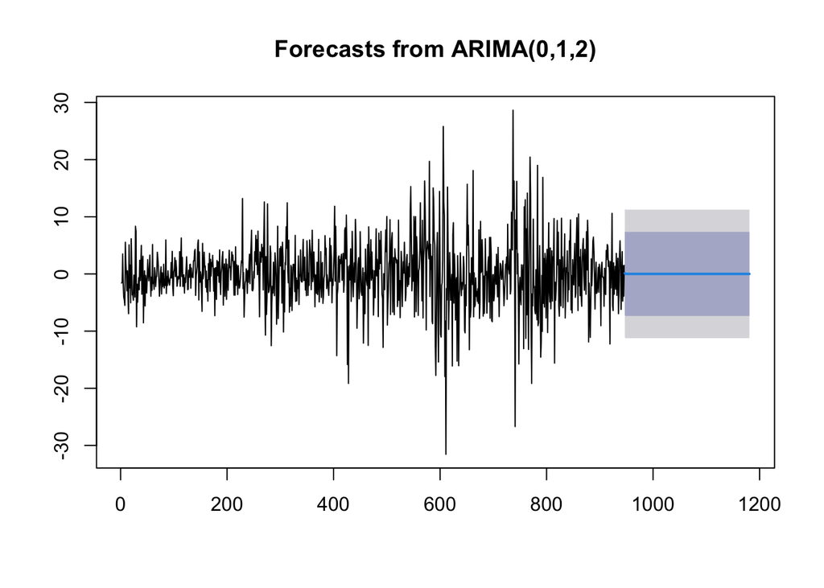

```r
data.ramalan.da <- ramalan.da$mean
plot(ramalan.da)
```

Berdasarkan hasil plot ramalan di atas, dapat dilihat bahwa ramalan ARIMA(0,1,2) cenderung stabil hingga akhir periode. Selanjutnya, dapat dicari nilai akurasi antara hasil ramalan dengan data uji sebagai berikut.

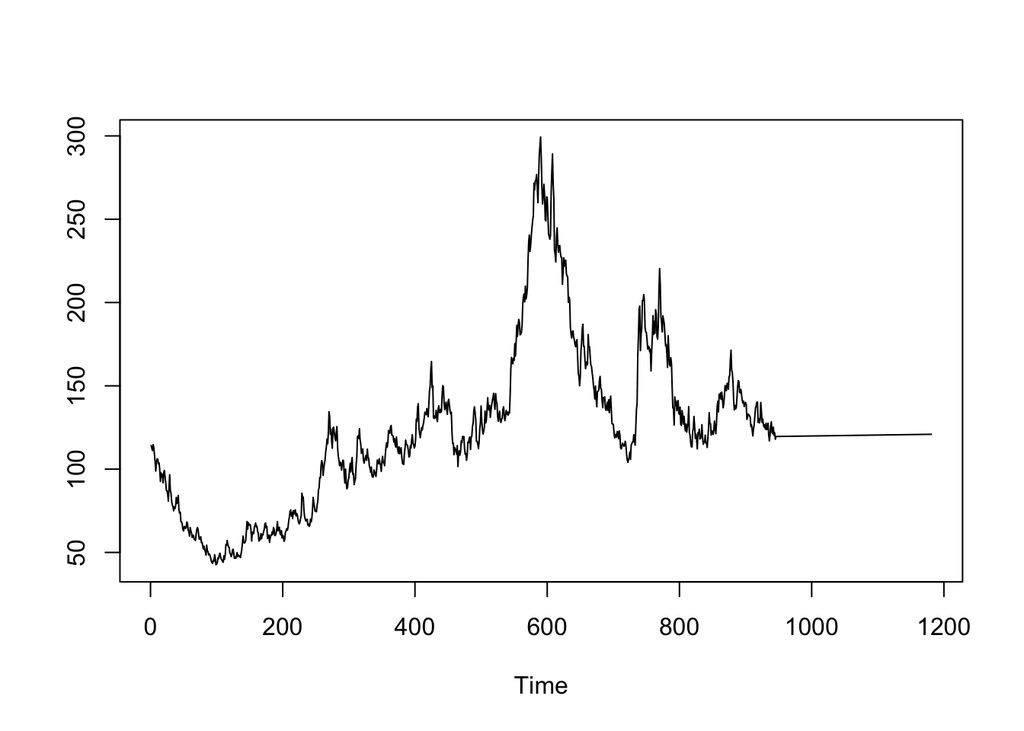

```r
pt_1 <- train.ts[946] #nilai akhir data latih
hasil.forc.Diff <- data.ramalan.da
hasil <- diffinv(hasil.forc.Diff, differences = 1) + pt_1
#has.1 sama hasilnta dengan: cumsum(c(pt_1,hasil.forc.Diff))
ts.plot(train.ts,hasil)
```

```r
perbandingan.da<-matrix(data=c(head(test.ts, n=235), hasil[-1]),
                     nrow = 235, ncol = 2)
colnames(perbandingan.da)<-c("Aktual","Hasil Forecast")
perbandingan.da
```

```
##        Aktual Hasil Forecast
##   [1,] 120.35       119.5972
##   [2,] 118.85       119.6028
##   [3,] 116.95       119.6084
##   [4,] 117.20       119.6141
##   [5,] 118.15       119.6197
##   [6,] 117.45       119.6253
##   [7,] 117.30       119.6310
##   [8,] 115.75       119.6366
##   [9,] 120.35       119.6423
##  [10,] 120.45       119.6479
##  [11,] 115.25       119.6535
##  [12,] 113.95       119.6592
##  [13,] 120.40       119.6648
##  [14,] 122.75       119.6704
```

[output cut: 221 more lines]

```r
accuracy(ts(hasil[-1]), head(test.ts, n=235))
```

```
##                ME     RMSE      MAE      MPE     MAPE      ACF1 Theil's U
## Test set 18.42236 51.54467 34.78448 4.491317 20.87863 0.9816775  6.111461
```

Dari hasil diperoleh nilai MAPE 20.87863 yang cukup layak untuk menggambarkan model deret waktu